# TP1: Linear models — Correction

Author

Lionel Hertzog

Published

September 11, 2026

## 1 Objective

The aim of this practical coding session is to go through the different steps of working with regression models using a simple linear model as an example:

1. Gather the data
2. Fit the model
3. Check model assumptions
4. Interpret the model

The dataset contains plot-level tree biomass and a proxy for soil fertility in the Vosges sylvoecoregion.

## 2 Gather the data

### 2.1 1. Load the data

We first load the `dat_tp1.csv` file.

```r
here::i_am("practicals/tp1_correction.qmd")
dat <- read.csv("../data/dat_tp1.csv")
```

The variables are:

- `idp`: plot ID
- `biomass`: above- and belowground tree biomass, in tonnes of dry matter per hectare
- `troph_r`: soil fertility proxy computed from the flora, ranging from 0 (acid soils) to 11 (calcareous soils)

### 2.2 2. Explore and clean the data

We begin by looking at the structure and basic summaries of the dataset.

```r
head(dat)
```

```
     idp   biomass troph_r
1 729317 423.39330 3.84374
2 758280 112.83840 2.95443
3 772844  76.99200 2.15281
4 761676  47.98659 1.03467
5 722455 218.33513 2.35393
6 738018 189.81802 2.91934
```

```r
str(dat)
```

```
'data.frame':   3579 obs. of  3 variables:
 $ idp    : int  729317 758280 772844 761676 722455 738018 777046 714754 703094 764732 ...
 $ biomass: num  423 113 77 48 218 ...
 $ troph_r: num  3.84 2.95 2.15 1.03 2.35 ...
```

```r
summary(dat)
```

```
      idp             biomass            troph_r
 Min.   :    127   Min.   :   0.498   Min.   :0.2541
 1st Qu.: 473917   1st Qu.: 135.113   1st Qu.:1.6669
 Median : 972456   Median : 223.044   Median :2.4090
 Mean   :1001500   Mean   : 232.211   Mean   :2.7922
 3rd Qu.:1531706   3rd Qu.: 313.977   3rd Qu.:3.5615
 Max.   :2054819   Max.   :1113.858   Max.   :8.7918
                   NA's   :169        NA's   :4
```

It is also useful to visualise the relationship between the two variables of interest.

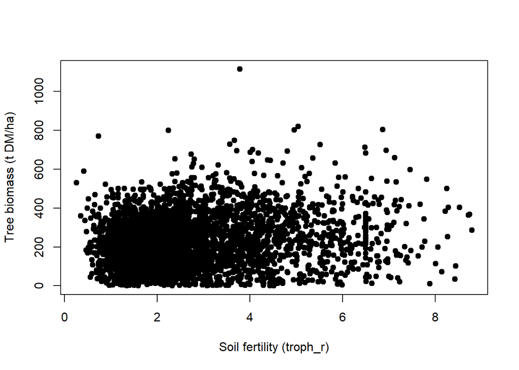

```r
plot(
  dat$troph_r,
  dat$biomass,
  xlab = "Soil fertility (troph_r)",
  ylab = "Tree biomass (t DM/ha)",
  pch = 19
)
```

We should also check for missing values:

```r
colSums(is.na(dat))
```

```
    idp biomass troph_r
      0     169       4
```

If missing values are present, they cannot be used to fit the model for observations where either `biomass` or `troph_r` is missing. For this practical, we therefore use complete observations for the model:

```r
dat_complete <- na.omit(dat[, c("biomass", "troph_r")])

nrow(dat_complete)
```

```
[1] 3406
```

**Conclusion.** Before fitting a model, it is important to check that the variables have plausible values, that there are no obvious data-entry errors, and that missing values are dealt with explicitly. The exploratory plot also gives us a first idea of whether a linear relationship is plausible.

## 3 Fit the model

We want to describe the relationship between tree biomass and soil fertility using:

$$biomass = \beta_0 + \beta_1 \times troph\_r + \epsilon,
\qquad
\epsilon \sim N(0,\sigma_{res})$$

The corresponding R model is:

```r
m <- lm(biomass ~ troph_r, data = dat_complete)

summary(m)
```

```
Call:
lm(formula = biomass ~ troph_r, data = dat_complete)

Residuals:
    Min      1Q  Median      3Q     Max
-291.00  -96.26   -5.63   84.23  867.95

Coefficients:
            Estimate Std. Error t value Pr(>|t|)
(Intercept)  193.746      4.722  41.027   <2e-16 ***
troph_r       13.778      1.487   9.265   <2e-16 ***
---
Signif. codes:  0 '***' 0.001 '**' 0.01 '*' 0.05 '.' 0.1 ' ' 1

Residual standard error: 131 on 3404 degrees of freedom
Multiple R-squared:  0.0246,    Adjusted R-squared:  0.02431
F-statistic: 85.85 on 1 and 3404 DF,  p-value: < 2.2e-16
```

The two main quantities to look at in the coefficient table are the estimates of the intercept and slope:

```r
coef(m)
```

```
(Intercept)     troph_r
  193.74640    13.77794
```

## 4 Check the model

Before interpreting the coefficients, we need to check whether the assumptions of the linear model are reasonable.

The assumptions considered in this practical are, in decreasing order of importance:

1. Validity of the data
2. Representativeness of the data
3. Linearity and additivity of the relationship
4. Independence of observations
5. Constant variance of residuals (homoscedasticity)
6. Normality of residuals

The first two assumptions, and partly independence, require knowledge of how the data were collected and cannot be established from a diagnostic plot alone.

For the remaining assumptions, we use **DHARMa**, which provides simulated residual diagnostics.

### 4.1 1. Simulate residuals

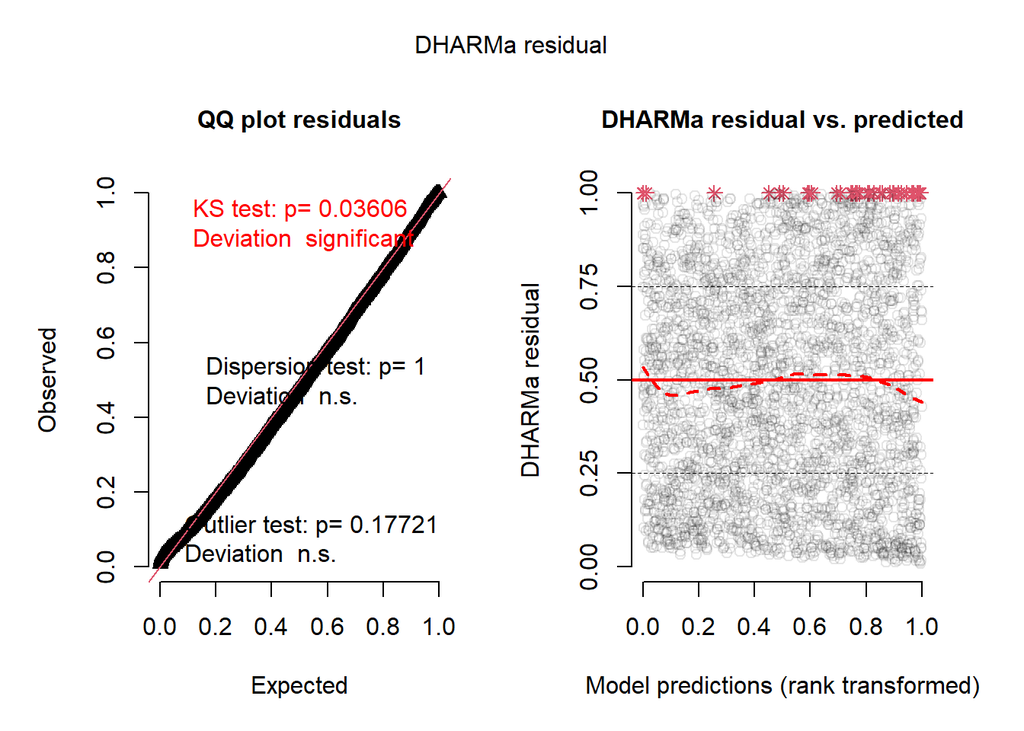

```r
library(DHARMa)

res <- simulateResiduals(m)

plot(res)
```

The DHARMa diagnostic plot provides a general overview of the simulated residuals. The left-had side plot is similar to a QQ plot - the black points should fall on the red line - and provide three tests: outliers, dispersion and distribution. The results show deviation from expected for the distribution of the residuals but this deviation is of very small magnitude:

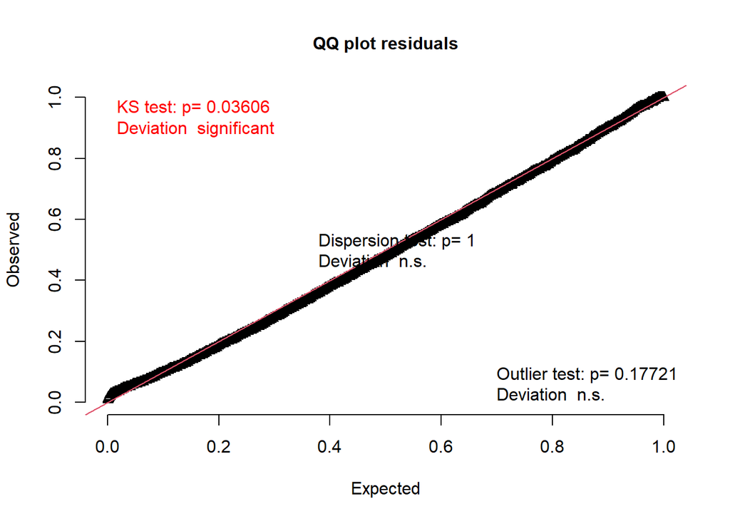

```
    Asymptotic one-sample Kolmogorov-Smirnov test

data:  simulationOutput$scaledResiduals
D = 0.02428, p-value = 0.03606
alternative hypothesis: two-sided
```

```r
testUniformity(res)
```

The right-hand side plot check for homogeneity of the variance and linearity of the relation, the dashed line(s) should fall on the full line(s). Here things look rather ok.

### 4.2 2. Check for constant variance

We can investigate whether residual variability changes with the predicted values:

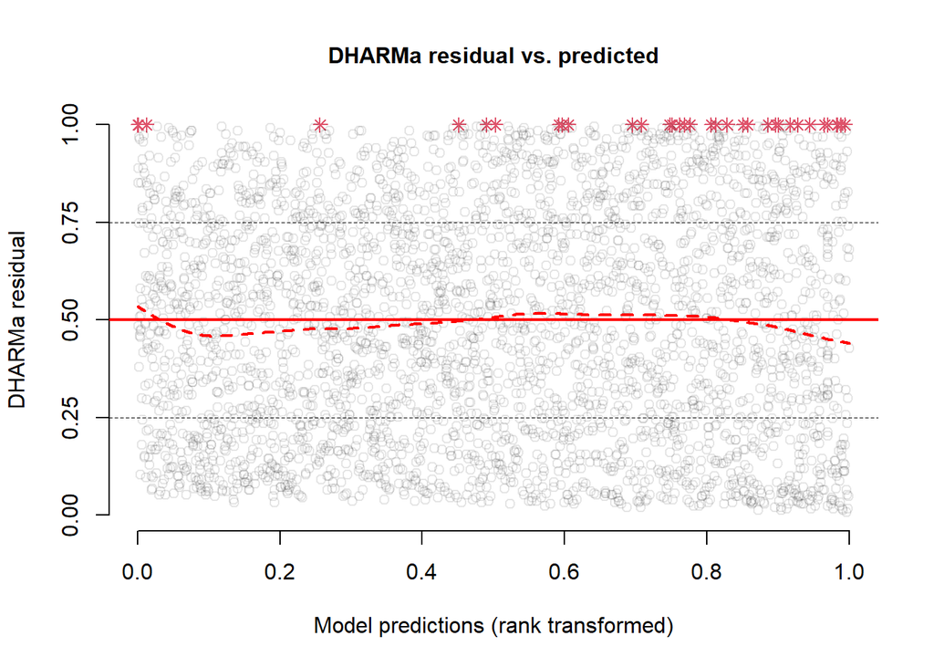

```r
plotResiduals(res)
```

**Interpretation.**

For a linear model with constant residual variance, we expect the residuals to be distributed without a systematic change in spread across the range of fitted values.

A funnel-shaped pattern would suggest heteroscedasticity: the variance of biomass would change with the expected biomass.

A roughly homogeneous cloud of residuals provides no strong evidence against the constant-variance assumption, which is the case here.

### 4.3 3. Check the linearity of the relationship

To assess whether the relationship between soil fertility and biomass is adequately represented by a straight line, we can plot the residuals against `troph_r`:

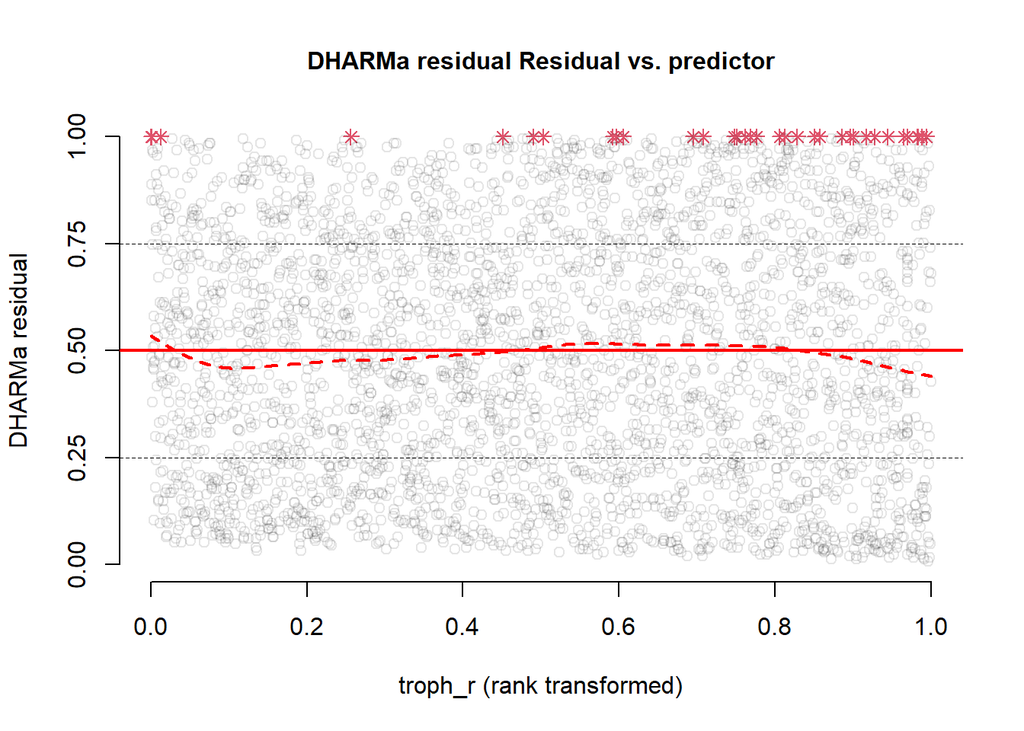

```r
plotResiduals(
  res,
  form = dat_complete$troph_r
)
```

If the linear model is appropriate, there should be no clear systematic pattern in the residuals.

For example, a curved pattern would suggest that the relationship is not adequately described by:

$$biomass = \beta_0 + \beta_1 \times troph_r.$$

In contrast, a residual pattern centred around zero without obvious curvature is consistent with the linearity assumption, this is the case here.

## 5 Model interpretation

### 5.1 1. Interpret the model coefficients

The model coefficients can be extracted with:

```r
coef(summary(m))
```

```
             Estimate Std. Error   t value      Pr(>|t|)
(Intercept) 193.74640   4.722355 41.027496 2.438100e-299
troph_r      13.77794   1.487049  9.265291  3.354119e-20
```

The intercept is:

```r
beta0 <- coef(m)[["(Intercept)"]]
beta0
```

```
[1] 193.7464
```

and the slope is:

```r
beta1 <- coef(m)[["troph_r"]]
beta1
```

```
[1] 13.77794
```

The residual standard deviation is:

```r
sigma_res <- sigma(m)
sigma_res
```

```
[1] 131.047
```

The interpretation should be expressed in terms of the original variables.

**Intercept ($\beta_0$).**

The intercept is the predicted tree biomass when `troph_r = 0`. In this dataset, this corresponds to the predicted biomass of 193 t DM / ha for a plot with the lowest value of the soil-fertility index.

It is important to distinguish statistical interpretation from ecological interpretation: the intercept is only particularly meaningful if `troph_r = 0` represents a relevant value within the observed range.

**Slope ($\beta_1$).**

The slope is the expected change in tree biomass associated with a one-unit increase in the soil-fertility index. The model estimated a slope of 13.77, meaning a positive effect of soil fertility on tree biomass.

**Residual standard deviation ($\sigma_{res}$).**

The residual standard deviation describes the typical magnitude of the unexplained variation, here 131, in biomass around the regression line, in the same units as biomass (tonnes of dry matter per hectare).

### 5.2 2. Plot the regression line and 95% confidence interval

The `ggeffects` package provides a convenient way of obtaining predictions from the model.

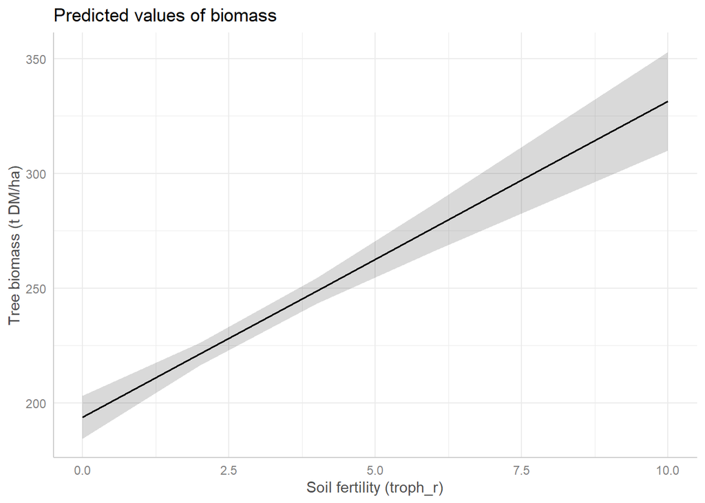

```r
library(ggplot2)
library(ggeffects)

pred <- predict_response(m, terms = "troph_r")

plot(pred) +
  labs(
    x = "Soil fertility (troph_r)",
    y = "Tree biomass (t DM/ha)"
  )
```

The shaded region represents the **95% confidence interval for the estimated mean relationship**.

It is important not to confuse this with a prediction interval for individual plots. The confidence interval describes uncertainty in the estimated **mean biomass** at each value of soil fertility; individual observations will generally show considerably more variability.

We can also inspect the prediction table:

```r
head(pred)
```

```
# Predicted values of biomass

troph_r | Predicted |         95% CI
------------------------------------
      0 |    193.75 | 184.49, 203.01
      2 |    221.30 | 216.33, 226.28
      4 |    248.86 | 243.22, 254.49
      6 |    276.41 | 266.08, 286.75
      8 |    303.97 | 288.16, 319.78
     10 |    331.53 | 310.06, 352.99
```

## 6 Final interpretation

Tree biomass shows a positive linear association with the soil-fertility index. For each one-unit increase in `troph_r`, predicted biomass changes by 13.77 t DM/ha. The residual diagnostics do not indicate important departures from the assumptions of constant variance and linearity. The residual standard deviation is approximately 131 t DM/ha, indicating the typical magnitude of unexplained variation around the regression relationship.